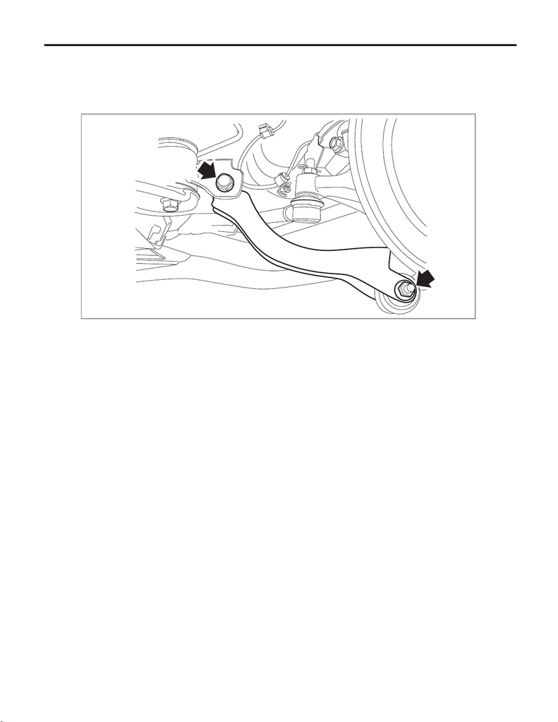

RS-16

Rear Trailing Link

REAR SUSPENSION

5. Rear Trailing Link

A: REMOVAL

1) Lift up the vehicle, and then remove the rear wheels.

2) Remove the bolts and nuts, and then remove the trailing link.

B: INSTALLATION

CAUTION:

• For parts which are not reusable, always use new parts.

• Always tighten the bushing in the state where the vehicle is at curb weight and the wheels are in

full contact with the ground.

1) Install the trailing link.

Tightening torque:

110 N·m (11.2 kgf-m, 81.1 ft-lb)

2) Install the rear wheels and lower the vehicle.

Tightening torque:

120 N·m (12.2 kgf-m, 88.5 ft-lb)

RS-00531

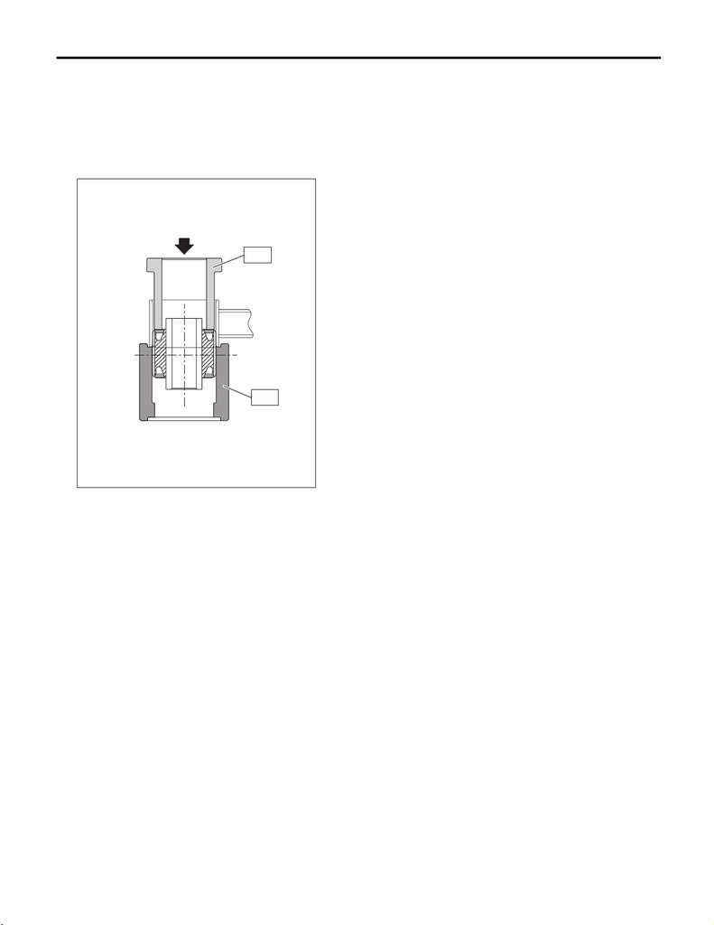

RS-17

Rear Trailing Link

REAR SUSPENSION

C: DISASSEMBLY

1. BUSHING A - TRAILING LINK

Using the ST, push out the bushing A - trailing link.

Preparation tool:

ST-A: INSTALLER (20099FG000)

ST-B: INSTALLER & REMOVER (BASE) (20099PA010)

2. BUSHING - TRAILING LINK

For the removal procedure of bushing - trailing link, refer to “Rear Axle” in the “DRIVE SHAFT SYSTEM” sec-

tion. <Ref. to DS-38, BUSHING - TRAILING LINK, DISASSEMBLY, Rear Axle.>

ST-B

RS-00425

ST-A

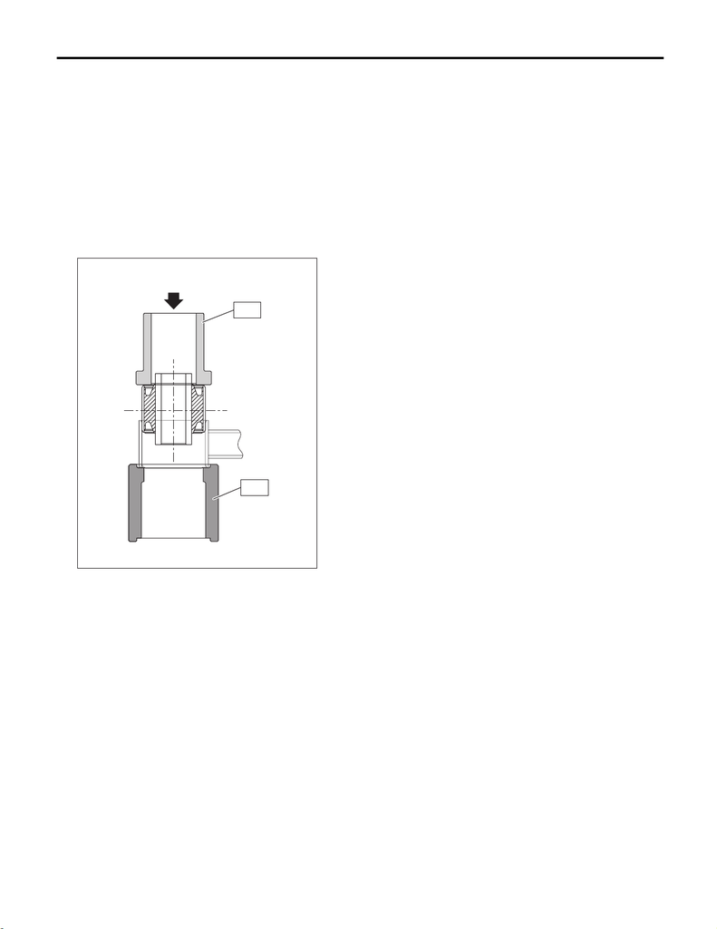

RS-18

Rear Trailing Link

REAR SUSPENSION

D: ASSEMBLY

1. BUSHING A - TRAILING LINK

1) Before assembly, inspect the following items and replace any faulty part with a new one.

• Perform visual check for damage or bend on the trailing link.

• Visually check the bushing for abnormal cracks, fatigue or damage.

2) Using the ST-A and ST-B, press-fit the bushing.

CAUTION:

Make sure to press the bushing straight in.

Preparation tool:

ST-A: INSTALLER (20099FG000)

ST-B: INSTALLER & REMOVER (BASE) (20099PA010)

2. BUSHING - TRAILING LINK

For the installation procedure of bushing - trailing link, refer to “Rear Axle” in the “DRIVE SHAFT SYSTEM”

section. <Ref. to DS-38, BUSHING - TRAILING LINK, DISASSEMBLY, Rear Axle.>

ST-B

RS-00426

ST-A